# Reproducible Research: Peer Assessment 1

## Loading and preprocessing the data

- We load the dply library for various subsetting functions.
- We download a fresh copy and unzip the file.
- We place the data in a raw table.
- We move the data to a target data so we can begin manipulating.

```r
library("dplyr")
```

```r
library("timeDate")
download.file("https://d396qusza40orc.cloudfront.net/repdata%2Fdata%2Factivity.zip", "activity.zip")
unzip ("activity.zip", exdir= "./data")                 ##  Unzip the file.
rawData <- read.csv ("./data/activity.csv")             ##  Read the CSV Files into a Raw Location
targetData <- rawData[complete.cases(rawData),]         ##  Remove NA's
targetData <- arrange(targetData, date)                 ##  Arrange in Date Order
```

We begin working on the starting example by making further changes to the data.  
- We remove NA’s for Part One.  
- We arrange by Date to making plotting easier later.

```r
targetData <- rawData[complete.cases(rawData),]         ##  Remove NA's
targetData <- arrange(targetData, date)                 ##  Arrange in Date Order
activityData <- arrange(targetData, interval)           ##  Arrange in interval Order
```

## What is mean total number of steps taken per day?

- We convert our factors to dates to make them a little easier to work with.
- We aggregate the daily steps by date, using aggregate to sum the values.
- Finally we pretty up the column names a bit for clarity and ease of use.
- We also calculate our mean and median for later use in the plot.

```r
targetData$date <- as.Date(targetData$date)                             ##  Convert factors to date format.
targetData <- aggregate(targetData$steps, list(targetData$date), sum)   ##  Builds SUM Aggregate
colnames(targetData) <- c("Date", "Daily_Steps")
avgdlystps <- mean(targetData$Daily_Steps)
meddlystps <- median(targetData$Daily_Steps)
```

### Results - Daily Steps

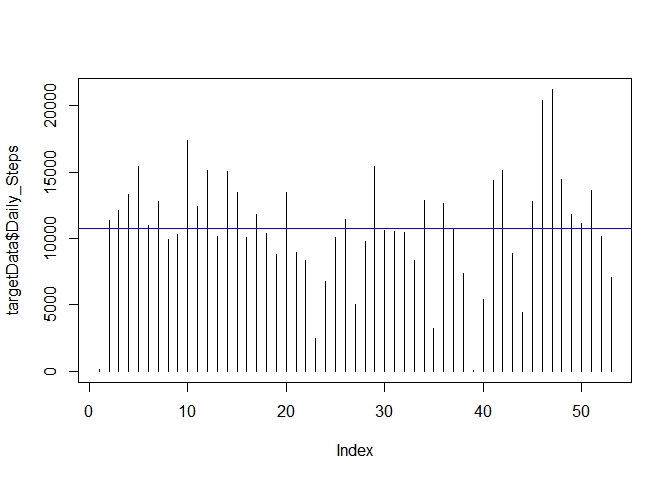

```r
        plot(targetData$Daily_Steps,type="h")
        abline(h=avgdlystps, col="Red")
        abline(h=meddlystps, col="Blue")
```

```r
        print(c("Average Daily Steps - ", as.character(avgdlystps)))
```

```
## [1] "Average Daily Steps - " "10766.1886792453"
```

```r
        print(c("Median Daily Steps - ", as.character(meddlystps)))
```

```
## [1] "Median Daily Steps - " "10765"
```

## What is the average daily activity pattern?

The average steps for each interval, across all days is listed below.  
-We create a directory and complete preparing the data. -We plot the average steps for each interval, across all days. -We find the maximum value and identify the interval that prepares that below.

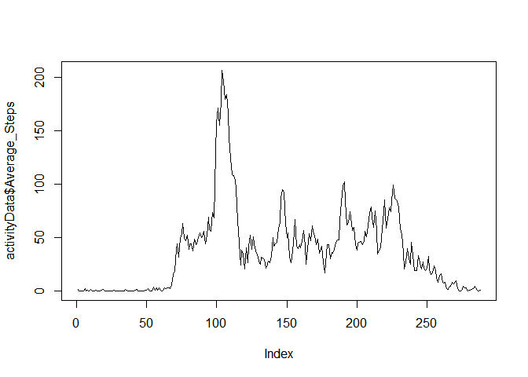

```r
        activityData <- aggregate(activityData$steps, list(activityData$interval), mean)
        colnames(activityData) <- c("Interval", "Average_Steps")
        plot(activityData$Average_Steps, type="l")
```

```r
        print("The interval with the greatest number of steps is averaged across all days is")
```

```
## [1] "The interval with the greatest number of steps is averaged across all days is"
```

```r
        print(as.character(activityData[activityData$Average_Steps==max(activityData$Average_Steps),]))
```

```
## [1] "835"              "206.169811320755"
```

## Imputing missing values

The total number of NA values in the data set are -

```r
        NADataSet <- rawData
        print(c("Total NA values is the dataset are - ", sum(is.na(rawData))))
```

```
## [1] "Total NA values is the dataset are - "
## [2] "2304"
```

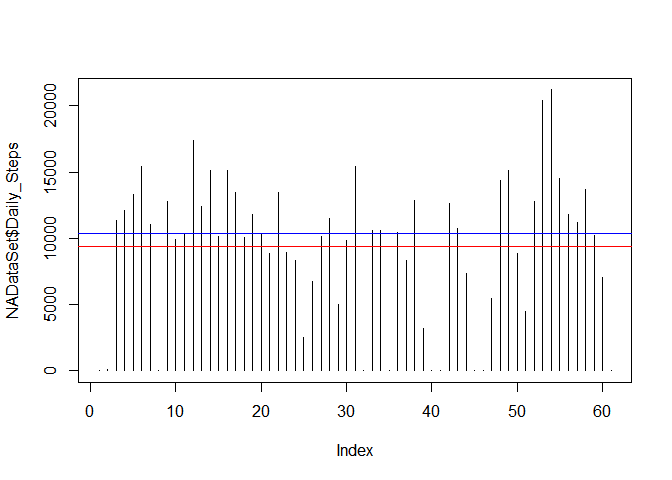

```r
        medianNA <- median(NADataSet$steps, na.rm = TRUE)
        NADataSet[is.na(NADataSet)] <- 0
        write.csv(NADataSet, file = "./data/NADataSet.csv")

        NADataSet$date <- as.Date(NADataSet$date)             ##  Convert factors to date format.
        NADataSet <- aggregate(NADataSet$steps, list(NADataSet$date), sum)    ##  Builds SUM Aggregate
        colnames(NADataSet) <- c("Date", "Daily_Steps")

        NAavgdlystps <- mean(NADataSet$Daily_Steps)
        NAmeddlystps <- median(NADataSet$Daily_Steps)


        plot(NADataSet$Daily_Steps,type="h")
        abline(h=NAavgdlystps, col="Red")
        abline(h=NAmeddlystps, col="Blue")
```

```r
        print(c("Average Daily Steps - ", as.character(NAavgdlystps)))
```

```
## [1] "Average Daily Steps - " "9354.22950819672"
```

```r
        print(c("Median Daily Steps - ", as.character(NAmeddlystps)))
```

```
## [1] "Median Daily Steps - " "10395"
```

## Are there differences in activity patterns between weekdays and weekends

There are clear differences in patterns between weekend weekday activity. Weekends show activity throughout the day versus weekday activity is early in the day. Why is interesting, I would imagine that scheduled physical activity would be early or before work during the weekday and throughout the day on the weekend….

To complete this, I loaded my NA data, aggregated the weekdays and weekend together. I created two plots.

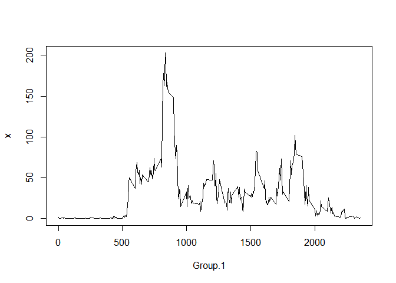

```r
        wvwData <- read.csv("./data/NADataSet.csv")
        wvwData <- wvwData[,2:4]
        wvwData$date <- as.Date(wvwData$date)

        measures.wd <- wvwData[isWeekday(wvwData$date),]
        measures.we <- wvwData[isWeekend(wvwData$date),]
        measures.wd <- aggregate(measures.wd$steps, list(measures.wd$interval), mean)
        measures.we <- aggregate(measures.we$steps, list(measures.we$interval), mean)

        plot(measures.wd, type="l")
```

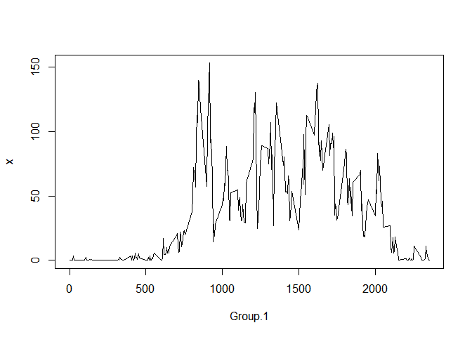

```r
        plot(measures.we, type="l")
```